# Choosing MGB Biobank asthmatic subject/sample numbers for further omics study

Demographics, lung function & medication

MHuang

2/8/2021

# 1. Read in lists and exclude

Exclude:

- existing PEGASUS subjects
- subjects with no plasma sample
- non-asthmatics

```r
asthma <- fread(asthma_fname); nrow(asthma)
```

```
## [1] 17773
```

```r
pegasus1_id <- fread(pegasus1_id_fname)

asthma[, ':='(in_pegasus1 = ifelse(Biobank_Subject_ID %in% pegasus1_id$SubjectID, 1, 0),
              plasma_existence = Plasma_Existence_Yes_No_To_6_30_2020,
              asthma_existence = Asthma_current_or_past_history_custom_PPV_0_80PPV_Existence_Yes_No,
              asthma_ppv = Asthma_current_or_past_history_custom_PPV_0_80PPV_List_of_All_Values,
              copd_existence = COPD_current_or_past_history_custom_PPV_0_75PPV_Existence_Yes_No,
              copd_ppv = COPD_current_or_past_history_custom_PPV_0_75PPV_List_of_All_Values)]

asthma[, .N, .(in_pegasus1, plasma_existence, asthma_existence)][order(in_pegasus1, plasma_existence)]
```

```
##    in_pegasus1 plasma_existence asthma_existence    N
## 1:           0                                      3
## 2:           0               No              Yes 8930
## 3:           0               No               No   33
## 4:           0              Yes              Yes 8214
## 5:           0              Yes               No   21
## 6:           1               No              Yes   12
## 7:           1              Yes              Yes  560
```

```r
asthma[plasma_existence == "Yes" & asthma_existence == "Yes", .N,
       .(has_first_colldate = !is.na(Plasma_Date_First_To_6_30_2020),
         has_last_colldate = !is.na(Plasma_Date_Most_Recent_To_6_30_2020),
         missing_asthma_ppv = is.na(asthma_ppv), asthma_ppv_gt85 = asthma_ppv > 0.85,
         asthma_ppv_gt90 = asthma_ppv > 0.9, asthma_ppv_gt95 = asthma_ppv > 0.95)]
```

```
##    has_first_colldate has_last_colldate missing_asthma_ppv asthma_ppv_gt85
## 1:               TRUE              TRUE              FALSE            TRUE
## 2:               TRUE              TRUE              FALSE            TRUE
## 3:               TRUE              TRUE              FALSE           FALSE
##    asthma_ppv_gt90 asthma_ppv_gt95    N
## 1:            TRUE           FALSE 4093
## 2:           FALSE           FALSE 3902
## 3:           FALSE           FALSE  779
```

```r
## Plasma collection dates from Biobank

plasma_dates <- read_xlsx(plasma_dates_fname) %>%
        as.data.table() %>%
        setnames(c("SUBJECTID", "Plasma (ml)"), c("Biobank_Subject_ID", "Plasma_ml"))
plasma_dates[, ':='(Biobank_Subject_ID = as.integer(Biobank_Subject_ID),
                    COLLECT_DATE = as.Date(COLLECT_DATE, format = "%y-%m-%d"))]
setkey(plasma_dates, Biobank_Subject_ID, COLLECT_DATE)

plasma_dates_per_subj <- plasma_dates[, .(n_plasma_date = .N,
                                          all_plasma_date = str_c(COLLECT_DATE, collapse = ";"),
                                          first_plasma_date = head(COLLECT_DATE, 1),
                                          last_plasma_date = tail(COLLECT_DATE, 1)),
                                      by = Biobank_Subject_ID]

asthma <- merge(asthma, plasma_dates_per_subj, by = "Biobank_Subject_ID", all.x = T)
asthma[, .N, .(plasma_existence, has_plasma_collection_date = !is.na(n_plasma_date))]
```

```
##    plasma_existence has_plasma_collection_date    N
## 1:               No                      FALSE 8975
## 2:              Yes                       TRUE 8787
## 3:              Yes                      FALSE    8
## 4:                                       FALSE    3
```

```r
## Generate potential subjects selection pool

tmp_cols <- c(colnames(asthma)[1:which(colnames(asthma) == "Age_Range")], "in_pegasus1",
              "plasma_existence", "asthma_existence", "asthma_ppv", "copd_existence", "copd_ppv",
              colnames(plasma_dates_per_subj)[-1])
pool <- asthma[asthma_existence == "Yes" & !is.na(n_plasma_date),
               ..tmp_cols]; nrow(pool)
```

```
## [1] 8766
```

```r
## Demographics

pool[, summary(Age)]
```

```
##    Min. 1st Qu.  Median    Mean 3rd Qu.    Max.
##    7.00   41.00   57.00   54.82   68.00   98.00
```

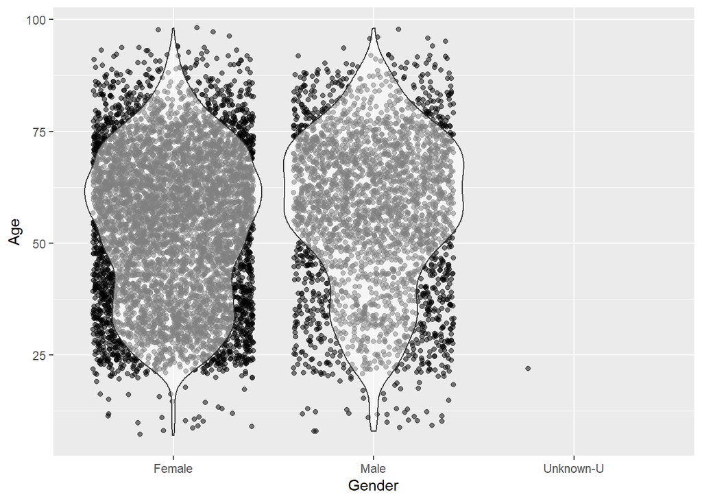

```r
ggplot(pool, aes(x = Gender, y = Age)) +
        geom_jitter(alpha = 0.5) +
        geom_violin(alpha = 0.5)
```

```r
pool[, race := case_when(Race %in% c("BLACK OR AFRICAN AMERICAN", "Black-BLACK",
                                     "Hispanic Black-BLACK OR AFRICAN AMERICAN@HISPANIC") ~ "Black",
                         Race %in% c("White-WHITE", "Hispanic White-WHITE@HISPANIC") ~ "White",
                         Race %in% c("Other-OTHER") ~ "Other",
                         Race %in% c("Not Recorded-DECLINED", "Not Recorded-UNKNOWN", "Not Recorded-U",
                                     "Not Recorded-@", "Not Recorded-NOT GIVEN") ~ "Unknown",
                         Race %in% c("Hispanic-HISPANIC OR LATINO", "Hispanic-OTHER@HISPANIC",
                                     "Hispanic-HISPANIC OR LATINO@HISPANIC", "Hispanic-HISPANIC",
                                     "Hispanic-DECLINED@HISPANIC", "Hispanic-HISPANIC@HISPANIC",
                                     "Hispanic-@HISPANIC") ~ "Hispanic",
                         Race %in% c("Asian-ASIAN") ~ "Asian",
                         Race %in% c("American Indian-AMERICAN INDIAN OR ALASKA NATIVE") ~ "American Indian/Alaska Native",
                         Race %in% c("Hawaiian-NATIVE HAWAIIAN OR OTHER PACIFIC ISLANDER") ~ "Hawaiian/Pacific Islander")]
pool[, .N, race][, pct := N/sum(N)*100] %>% print(digits = sig_digits)
```

```
##                             race    N     pct
## 1:                         White 7103 81.0290
## 2:                         Other  338  3.8558
## 3:                         Black  586  6.6849
## 4:                      Hispanic  334  3.8102
## 5:     Hawaiian/Pacific Islander    3  0.0342
## 6: American Indian/Alaska Native   21  0.2396
## 7:                       Unknown  200  2.2815
## 8:                         Asian  181  2.0648
```

```r
## COPD existence

pool[, summary(copd_ppv)]
```

```
##    Min. 1st Qu.  Median    Mean 3rd Qu.    Max.    NA's
##   0.750   0.800   0.830   0.852   0.940   0.940    8470
```

```r
pool[, .N, .(copd_existence, copd_ppv_gt80 = copd_ppv > 0.80, copd_ppv_gt85 = copd_ppv > 0.85,
             copd_ppv_gt90 = copd_ppv > 0.9)][order(copd_existence, copd_ppv_gt80, copd_ppv_gt85, copd_ppv_gt90)]
```

```
##    copd_existence copd_ppv_gt80 copd_ppv_gt85 copd_ppv_gt90    N
## 1:             No            NA            NA            NA 8470
## 2:            Yes         FALSE         FALSE         FALSE   80
## 3:            Yes          TRUE         FALSE         FALSE  100
## 4:            Yes          TRUE          TRUE         FALSE   33
## 5:            Yes          TRUE          TRUE          TRUE   83
```

# 2. Lung function data availability

Variable names:

- n_pul_rec: number of pulmonary function test (pft, spirometry) records
- earliest_pul_rec: date of earliest pft record
- latest_pul_rec: date of latest pft record
- has_pul_rec: has any pft record

Suffix:

- _alltime: all time in system
- _bflastpl: all time prior to last plasma date
- _10ybflastpl: within 10 years prior to last plasma date
- _5ybflastpl: within 5 years prior to last plasma date

## 2.1. All available records

```r
filePathToPulTxt <- str_c(rpdr_file_header, "Pul_v2", rpdr_file_ending)
pul_id <- getPULIDs(filePathToPulTxt); nrow(pul_id)
```

```
## [1] "File processed."
```

```
## [1] 47713
```

```r
print(str_c("Unique number of subjects with pft data in all biobank asthmatics: ",
            pul_id[, length(unique(EMPI))]))
```

```
## [1] "Unique number of subjects with pft data in all biobank asthmatics: 5683"
```

```r
## Restrict to those with plasma

pul_id <- pul_id[EMPI %in% pool$EMPI, ]; nrow(pul_id)
```

```
## [1] 31008
```

```r
print(str_c("Unique number of asthmatics with pft data & plasma sample & not in PEGASUS: ",
            pul_id[, length(unique(EMPI))]))
```

[output not shown]

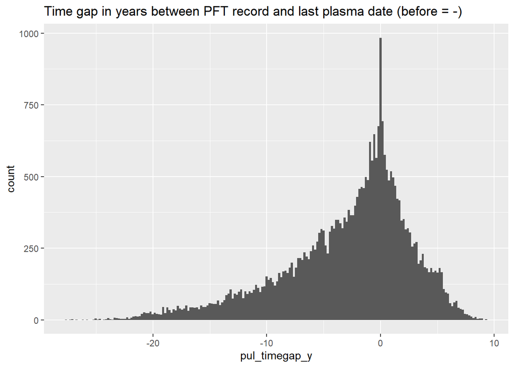

```r
pul_id <- merge(pul_id, pool[, .(EMPI, last_plasma_date)], by = "EMPI", all.x = T)


## Calculate timegap between pul record & last plasma date

pul_id[, pul_timegap_d := as.numeric(Date_Fmt - last_plasma_date)][, pul_timegap_y := pul_timegap_d/365.25]
ggplot(pul_id) +
        geom_histogram(aes(pul_timegap_y), bins = 200) +
        labs(title = "Time gap in years between PFT record and last plasma date (before = -)")
```

```r
## Function to generate variables on number of pul records under certain restriction

n_pul_rec_fnc <- function(restriction, varname_suffix) {
        pul_uniq_date <- eval(parse(text = str_c("unique(pul_id[", restriction,
                                                 ", .(EMPI, Date_Fmt, pul_timegap_d)])")))
        pul_per_subj <- pul_uniq_date[, .(n_pul_rec = .N,
                                          earliest_pul_rec = min(Date_Fmt),
                                          latest_pul_rec = max(Date_Fmt)), EMPI]
        pul_per_subj <- merge(pul_per_subj,
                              pul_uniq_date[pul_timegap_d < 0,
                                            .(closest_pul_rec_bf_timegap_d = max(pul_timegap_d)), EMPI],
                              by = "EMPI", all.x = T)
        pul_per_subj <- merge(pul_per_subj,
                              pul_uniq_date[pul_timegap_d >= 0,
                                            .(closest_pul_rec_af_timegap_d = min(pul_timegap_d)), EMPI],
                              by = "EMPI", all.x = T)
        setnames(pul_per_subj, c("EMPI", str_c(colnames(pul_per_subj)[-1], varname_suffix)))
        pool <- merge(pool, pul_per_subj, by = "EMPI", all.x = T)
        eval(parse(text = str_c("pool[, has_pul_rec", varname_suffix,
                                " := ifelse(!is.na(n_pul_rec", varname_suffix, "), 1, 0) %>% as.factor()]")))
        return(pool)
}


## Generate variables on number of pul records from all time in MGB system

pool <- n_pul_rec_fnc(restriction = "", varname_suffix = "_alltime")


## Examine data availability - all time in MGB system

# display_cols <- c("EMPI", "last_plasma_date", grep("_alltime", colnames(pool), value = T))
# datatable(pool[, ..display_cols], filter = "top")

pool[n_pul_rec_alltime >= 2, .N, .(has_pul_1ybf = closest_pul_rec_bf_timegap_d_alltime >= -365)]
```

```
##    has_pul_1ybf   N
## 1:        FALSE 999
## 2:         TRUE 664
## 3:           NA 234
```

```r
pool[n_pul_rec_alltime >= 2, .N, .(has_pul_1yaf = closest_pul_rec_af_timegap_d_alltime <= 365)]
```

```
##    has_pul_1yaf   N
## 1:           NA 722
## 2:         TRUE 665
## 3:        FALSE 510
```

```r
pool[n_pul_rec_alltime >= 2, ][closest_pul_rec_bf_timegap_d_alltime >= -365 |
                                 closest_pul_rec_af_timegap_d_alltime <= 365, .N]
```

```
## [1] 943
```

```r
pool[n_pul_rec_alltime >= 2, ][closest_pul_rec_bf_timegap_d_alltime >= -365 &
                                 closest_pul_rec_af_timegap_d_alltime <= 365, .N]
```

```
## [1] 386
```

## 2.2. All records before last plasma date

```r
pool <- n_pul_rec_fnc(restriction = "pul_timegap_d <= 0", varname_suffix = "_bflastpl")


## Examine data availability - before last plasma collection date

# display_cols <- c("EMPI", "last_plasma_date", grep("_bflastpl", colnames(pool), value = T))
# datatable(pool[, ..display_cols], filter = "top")
```

## 2.3. All records within 10 years before last plasma date

```r
pool <- n_pul_rec_fnc(restriction = "pul_timegap_d <= 0 & pul_timegap_y >= -10",
                      varname_suffix = "_10ybflastpl")


## Examine data availability - within 10 years before last plasma collection date

# display_cols <- c("EMPI", "last_plasma_date", grep("_10ybflastpl", colnames(pool), value = T))
# datatable(pool[, ..display_cols], filter = "top")
```

## 2.4. All records within 5 years before last plasma date

```r
pool <- n_pul_rec_fnc(restriction = "pul_timegap_d <= 0 & pul_timegap_y >= -5",
                      varname_suffix = "_5ybflastpl")


## Examine data availability - within 5 years before last plasma collection date

# display_cols <- c("EMPI", "last_plasma_date", grep("_5ybflastpl", colnames(pool), value = T))
# datatable(pool[, ..display_cols], filter = "top")
```

## 2.5. Compare data availability in different time frames

```r
pool[, .N, .(has_pul_rec_alltime, has_pul_rec_bflastpl, has_pul_rec_10ybflastpl, has_pul_rec_5ybflastpl)
     ][order(has_pul_rec_alltime, has_pul_rec_bflastpl, has_pul_rec_10ybflastpl, has_pul_rec_5ybflastpl)]
```

```
##    has_pul_rec_alltime has_pul_rec_bflastpl has_pul_rec_10ybflastpl
## 1:                   0                    0                       0
## 2:                   1                    0                       0
## 3:                   1                    1                       0
## 4:                   1                    1                       1
## 5:                   1                    1                       1
##    has_pul_rec_5ybflastpl    N
## 1:                      0 5556
## 2:                      0  642
## 3:                      0  445
## 4:                      0  460
## 5:                      1 1663
```

```r
pool[n_pul_rec_alltime >= 2 & Age >= 18, .N, .(has_pul_1ybf = closest_pul_rec_bf_timegap_d_alltime >= -365)]
```

```
##    has_pul_1ybf   N
## 1:        FALSE 999
## 2:         TRUE 659
## 3:           NA 223
```

```r
pool[n_pul_rec_alltime >= 2 & Age >= 18, .N, .(has_pul_1yaf = closest_pul_rec_af_timegap_d_alltime <= 365)]
```

```
##    has_pul_1yaf   N
## 1:           NA 722
## 2:         TRUE 654
## 3:        FALSE 505
```

```r
pool[n_pul_rec_alltime >= 2 & Age >= 18, ][closest_pul_rec_bf_timegap_d_alltime >= -365 |
                                             closest_pul_rec_af_timegap_d_alltime <= 365, .N]
```

```
## [1] 931
```

```r
pool[n_pul_rec_alltime >= 2 & Age >= 18, ][closest_pul_rec_bf_timegap_d_alltime >= -365 &
                                             closest_pul_rec_af_timegap_d_alltime <= 365, .N]
```

```
## [1] 382
```

# 3. Medication data

Variable names:

- n_ics_rec: number of ICS prescription records
- ics_rec_latest_timegap_d: date of latest ICS prescription - last plasma date in days
- has_ics_rec: has ICS prescription records
- n_ocs_rec: number of OCS prescription records
- ocs_rec_latest_timegap_d: date of latest OCS prescription - last plasma date in days
- has_ocs_rec: has OCS prescription records

```r
med <- fread(str_c(rpdr_file_header, "Med", rpdr_file_ending))
med[, unique(EMPI)] %in% pool[, EMPI] %>% table()
```

```
## .
## FALSE  TRUE
##  8977  8745
```

```r
med <- med[EMPI %in% pool$EMPI, ] # Restrict to subjects in selection pool

med[, Medication_Date := as.Date(Medication_Date, format = "%m/%d/%Y")]
med[, summary(Medication_Date)]
```

```
##         Min.      1st Qu.       Median         Mean      3rd Qu.         Max.
## "1979-10-04" "2012-07-09" "2015-05-05" "2014-07-06" "2017-10-27" "2020-06-23"
```

```r
med <- merge(med, pool[, .(EMPI, last_plasma_date)], by = "EMPI", all.x = T)
med[, med_timegap_d := as.numeric(Medication_Date - last_plasma_date)][, med_timegap_y := med_timegap_d/365.25]
med[, summary(med_timegap_y)]
```

```
##    Min. 1st Qu.  Median    Mean 3rd Qu.    Max.
## -39.565  -3.595  -0.397  -1.317   1.602   9.706
```

## 3.1. Parse out corticosteroids

```r
## Mapping file for medications of interest

med_map <- read_xlsx(med_map_fname) %>% as.data.table()
med_map_cs <- med_map[Medication_GWAS_Group %in% c("Oral Corticosteroids", "Inhaled Corticosteroids",
                                                   "Inhaled Corticosteroids and Long Acting Beta Agonists") |
                        Medication_Pegasus_Group %in% c("Oral Steroids", "Inhaled Steroids", "Cortisone",
                                                        "Hydrocortisone"), ]
datatable(med_map_cs[, .(Medication_Name, Medication_GWAS_Group, Medication_Pegasus_Group,
                         ICS_or_ICS_LABA, Medication_Biobank_Folder)])
```

|  | Medication_Name | Medication_GWAS_Group | Medication_Pegasus_Group | ICS_or_ICS_LABA | Medication_Biobank_Folder |
| --- | --- | --- | --- | --- | --- |
| 1 | Beclomethasone dipropionate | Inhaled Corticosteroids | Inhaled Steroids | yes | Anti-inflammatories, inhalation |
| 2 | Betamethasone |  | Inhaled Steroids | yes | Glucocorticoids |
| 3 | Budesonide | Inhaled Corticosteroids | Inhaled Steroids | yes | Anti-inflammatories, inhalation |
| 4 | Budesonide/formoterol | Inhaled Corticosteroids and Long Acting Beta Agonists | Inhaled Steroids | yes | Antiasthma, other |
| 5 | Ciclesonide | Inhaled Corticosteroids | Inhaled Steroids | yes | Anti-inflammatories, inhalation |
| 6 | Cortisone |  | Cortisone |  | Glucocorticoids |
| 7 | Dexamethasone | Inhaled Corticosteroids | Inhaled Steroids | yes | Anti-inflammatories, inhalation |
| 8 | Dexamethasone |  | Oral Steroids |  | Glucocorticoids |
| 9 | Flunisolide | Inhaled Corticosteroids | Inhaled Steroids | yes | Anti-inflammatories, inhalation |
| 10 | Fluticasone | Inhaled Corticosteroids | Advair | yes | Anti-inflammatories, inhalation |

[output cut: 9 more lines]

```r
med_condensed <- med %>% group_by(Medication) %>% summarise()
med_all_subgroups <- data.frame(Medication = character(),
                                Medication_Name = character(),
                                Medication_Biobank_Folder = character(),
                                Medication_GWAS_Group = character(),
                                Medication_Pegasus_Group = character())
for (m in 1:nrow(med_map_cs)) {
        med_subSampleGroup <- med_condensed %>% filter(grepl(med_map_cs[m, ]$Search_Term,
                                                             Medication,
                                                             ignore.case = med_map_cs[m, ]$Ignore.case,
                                                             perl = med_map_cs[m, ]$Perl)) %>%
                mutate(Medication_Name  = med_map_cs[m, ]$Medication_Name,
                       Medication_Biobank_Folder = med_map_cs[m, ]$Medication_Biobank_Folder,
                       Medication_GWAS_Group = med_map_cs[m, ]$Medication_GWAS_Group,
                       Medication_Pegasus_Group = med_map_cs[m, ]$Medication_Pegasus_Group)
        med_all_subgroups <- rbind(med_all_subgroups, med_subSampleGroup)
        rm(med_subSampleGroup)
}
med_all_subgroups <- as.data.table(med_all_subgroups)


## Remove duplicated records

med_all_subgroups[Medication %in% med_all_subgroups[duplicated(Medication), Medication], ]
```

```
##                                                                       Medication
## 1: Pulmicort flexhaler 180 mcg (budesonide inhalation powder 180 mcg) - LMR 5919
## 2: Pulmicort flexhaler 180 mcg (budesonide inhalation powder 180 mcg) - LMR 5919
## 3:                Id-Fluticasone Or Fluticasone/Salmeterol (2013p002453) Inhaler
## 4:                Id-Fluticasone Or Fluticasone/Salmeterol (2013p002453) Inhaler
##           Medication_Name       Medication_Biobank_Folder
## 1:             Budesonide Anti-inflammatories, inhalation
## 2:          Dexamethasone                 Glucocorticoids
## 3:            Fluticasone Anti-inflammatories, inhalation
## 4: Fluticasone/salmeterol               Antiasthma, other
##                                    Medication_GWAS_Group
## 1:                               Inhaled Corticosteroids
## 2:                                                  <NA>
## 3:                               Inhaled Corticosteroids
## 4: Inhaled Corticosteroids and Long Acting Beta Agonists
##    Medication_Pegasus_Group
## 1:         Inhaled Steroids
## 2:            Oral Steroids
## 3:                   Advair
## 4:                     <NA>
```

```r
med_all_subgroups <- med_all_subgroups[!(grepl("Pulmicort flexhaler 180 mcg", Medication) &
                                           Medication_Name == "Dexamethasone")]
med_all_subgroups <- med_all_subgroups[!(grepl("Id-Fluticasone Or Fluticasone/Salmeterol", Medication) &
                                           Medication_Name == "Fluticasone/salmeterol")]


## Add indicator for ICS/OCS/(hydro)cortisone

med_all_subgroups[, ':='(ocs = ifelse(Medication_GWAS_Group == "Oral Corticosteroids" |
                                        Medication_Pegasus_Group == "Oral Steroids", 1, 0),
                         ics = ifelse(Medication_GWAS_Group %in% c("Inhaled Corticosteroids",
                                                                   "Inhaled Corticosteroids and Long Acting Beta Agonists") |
                                        Medication_Pegasus_Group == "Inhaled Steroids", 1, 0),
                         cortisone_hydro = ifelse(Medication_Pegasus_Group %in% c("Cortisone", "Hydrocortisone"), 1, 0))]

med_cs <- merge(med, med_all_subgroups, by = "Medication")
med_cs[, unique(EMPI)] %in% pool[, EMPI] %>% table() # Number of subjects with corticosteroids med data
```

```
## .
## TRUE
## 7500
```

```r
med_cs[med_timegap_y <= 0, length(unique(EMPI))] # Number of subjects with corticosteroids med data before last plasma date
```

```
## [1] 6602
```

## 3.2. Number of ICS/OCS prescriptions prior to last plasma date

### 3.2.1. Within 1 year prior to last plasma date

```r
## Function to generate variables on ICS/OCS under certain restriction

cs_vars_fnc <- function(restriction, varname_suffix) {
        cs_tmp <- eval(parse(text = str_c("med_cs[med_timegap_y <= 0 & ", restriction, ", ]")))
        cs_per_subj <- cs_tmp[, .(n_ics_rec = sum(ics, na.rm = T),
                                  n_ocs_rec = sum(ocs, na.rm = T)), EMPI]
        cs_per_subj <- merge(cs_per_subj, cs_tmp[ics == 1, .(ics_rec_latest_timegap_d = max(med_timegap_d)), EMPI],
                             by = "EMPI", all.x = T)
        cs_per_subj <- merge(cs_per_subj, cs_tmp[ocs == 1, .(ocs_rec_latest_timegap_d = max(med_timegap_d)), EMPI],
                             by = "EMPI", all.x = T)
        setnames(cs_per_subj, c("EMPI", str_c(colnames(cs_per_subj)[-1], varname_suffix)))
        pool <- merge(pool, cs_per_subj, by = "EMPI", all.x = T)
        eval(parse(text = str_c("pool[, ':='(has_ics_rec", varname_suffix, " = ifelse(!is.na(n_ics_rec",
                                             varname_suffix, "), 1, 0) %>% as.factor(),
                                             has_ocs_rec", varname_suffix, " = ifelse(!is.na(n_ocs_rec",
                                             varname_suffix, "), 1, 0) %>% as.factor())]")))
        return(pool)
}


## Generate # of ICS/OCS prescriptions within 1 year prior to last plasma date

pool <- cs_vars_fnc(restriction = "med_timegap_y >= -1", varname_suffix = "_1ybflastpl")
```

### 3.2.2. Within 2 years prior to last plasma date

```r
## Generate # of ICS/OCS prescriptions within 2 years prior to last plasma date

pool <- cs_vars_fnc(restriction = "med_timegap_y >= -2", varname_suffix = "_2ybflastpl")
```

### 3.2.3. Within 3 years prior to last plasma date

```r
## Generate # of ICS/OCS prescriptions within 3 years prior to last plasma date

pool <- cs_vars_fnc(restriction = "med_timegap_y >= -3", varname_suffix = "_3ybflastpl")
```

### 3.2.4. Within 4 years prior to last plasma date

```r
## Generate # of ICS/OCS prescriptions within 4 years prior to last plasma date

pool <- cs_vars_fnc(restriction = "med_timegap_y >= -4", varname_suffix = "_4ybflastpl")
```

### 3.2.5. Within 5 years prior to last plasma date

```r
## Generate # of ICS/OCS prescriptions within 5 years prior to last plasma date

pool <- cs_vars_fnc(restriction = "med_timegap_y >= -5", varname_suffix = "_5ybflastpl")
```

# 4. Save selection pool data

```r
fwrite(pool, here(res_dir, "selection_pool.csv"))
```